# Exam 3

William Golden

First, let’s load the packages we need for this project.

```r
library(tidyverse)
library(ggplot2)
library(janitor)
library(modelr)
library(broom)
```

# Tasks:

**1. Load and clean FacultySalaries_1995.csv file and Re-create the graph**

Let’s load the csv file and rename it “df”.

```r
df <- read.csv("FacultySalaries_1995.csv")
```

To clean it, we will standardize the names using janitor package::clean_names, and we will remove a tier that is not listed on our target graph. We will then split the data into three sets (assistant, full time, and associate), select the columns we need, rename the columns titled “avg salary” to just “salary”, then recombine these subsets into a new, clean data set.

```r
df <- clean_names(df)

df <- df[!df$tier == "VIIB", ]

assist <- df %>%
  select(starts_with("avg_assist"),-ends_with("comp"),state,tier)

assist$rank <- "assist"

assist <- assist %>% rename(.,salary=avg_assist_prof_salary)

# assoc

assoc <- df %>%
  select(starts_with("avg_assoc"),-ends_with("comp"),state,tier)

assoc$rank <- "assoc"

assoc <- assoc %>% rename(.,salary=avg_assoc_prof_salary)


# Full

full <- df %>%
  select(starts_with("avg_full"),-ends_with("comp"),state,tier)

full$rank <- "full"

full <- full %>% rename(.,salary=avg_full_prof_salary)


# Combine data

clean <- full_join(assoc,assist) %>%
  full_join(full)
```

Here is what the clean data set looks like

```r
clean %>% glimpse
```

```
## Rows: 3,480
## Columns: 4
## $ salary <int> 382, 560, 494, 507, 369, 385, 394, 437, 379, 412, 303, 389, 304…
## $ state  <chr> "AK", "AK", "AK", "AK", "AL", "AL", "AL", "AL", "AL", "AL", "AL…
## $ tier   <chr> "IIB", "I", "IIA", "IIA", "IIA", "IIA", "IIB", "I", "IIB", "IIB…
## $ rank   <chr> "assoc", "assoc", "assoc", "assoc", "assoc", "assoc", "assoc", …
```

Now we make the graph!

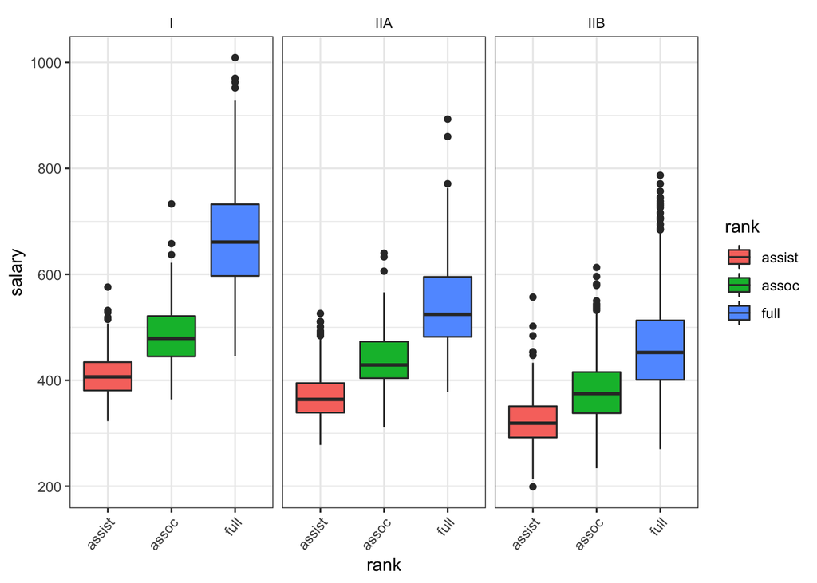

```r
clean %>%
  ggplot(aes(x=rank,y=salary, fill=rank))+
  geom_boxplot()+
  facet_wrap(~tier)+
  theme_bw()+
  theme(strip.background = element_blank())+
  theme(axis.text.x = element_text(angle = 50, hjust = 1))
```

**2. Build an ANOVA model and display the summary output in your report.**

Here, we built a model showing the affect of state,tier, and rank on salary and display the ANNOVA model summary.

```r
mod <- glm(data=clean,
           formula=salary~state+tier+rank)

test <- aov(mod)
summary(test)
```

```
##               Df   Sum Sq Mean Sq F value Pr(>F)
## state         50  5667124  113342   31.17 <2e-16 ***
## tier           2  7072361 3536180  972.56 <2e-16 ***
## rank           2 16526626 8263313 2272.66 <2e-16 ***
## Residuals   3297 11987752    3636
## ---
## Signif. codes:  0 '***' 0.001 '**' 0.01 '*' 0.05 '.' 0.1 ' ' 1
## 128 observations deleted due to missingness
```

**3. Load the “Juniper_Oils.csv” data and tidy it**

Let’s load the data set and select the columns we need. We will also rename the columns of the chemicals to the same names used on our target graph. Next, we will pivot longer the columns of chemicals and put them into a new column labeled “ChemicalID”. We will call this clean dataset “cleanoil”. That’s kind of funny since oil is not a very clean liquid.

```r
oil <- read.csv("Juniper_Oils.csv")

oil <- clean_names(oil)

cleanoil <- select(oil,"alpha_pinene","para_cymene","alpha_terpineol",
              "cedr_9_ene","alpha_cedrene","beta_cedrene",
              "cis_thujopsene","alpha_himachalene",
              "beta_chamigrene","cuparene","compound_1",
              "alpha_chamigrene","widdrol","cedrol","beta_acorenol"
              ,"alpha_acorenol","gamma_eudesmol","beta_eudesmol"
              ,"alpha_eudesmol","cedr_8_en_13_ol","cedr_8_en_15_ol",
              "compound_2","thujopsenal", "years_since_burn") %>%
  rename("alpha-acorenol"="alpha_acorenol",
             "alpha-pinene" ="alpha_pinene",
             "para-cymene" ="para_cymene",
             "alpha-terpineol" ="alpha_terpineol",
             "cedr-9-ene" ="cedr_9_ene",
             "alpha-cedrene"="alpha_cedrene",
             "beta-cedrene"="beta_cedrene",
             "cis-thujopsene" ="cis_thujopsene",
             "alpha-himachalene"="alpha_himachalene",
             "beta-chamigrene"="beta_chamigrene",
             "compound 1"="compound_1",
             "alpha-chamigrene" ="alpha_chamigrene",
             "beta-acorenol" ="beta_acorenol",
             "alpha-acorenol"="alpha_acorenol",
             "gamma-eudesmol" ="gamma_eudesmol",
             "beta-eudesmol" ="beta_eudesmol",
             "alpha-eudesmol"="alpha_eudesmol",
             "cedr-8-en-13-ol" ="cedr_8_en_13_ol",
             "cedr-8-en-15-ol" ="cedr_8_en_15_ol",
             "compound 2" ="compound_2",
             "YearsSinceBurn" ="years_since_burn")


cleanoil <- cleanoil %>%
  pivot_longer(c("alpha-pinene","para-cymene","alpha-terpineol",
                    "cedr-9-ene","alpha-cedrene","beta-cedrene",
                    "cis-thujopsene","alpha-himachalene",
                    "beta-chamigrene","cuparene","compound 1",
                    "alpha-chamigrene","widdrol","cedrol","beta-acorenol"
                    ,"alpha-acorenol","gamma-eudesmol","beta-eudesmol"
                    ,"alpha-eudesmol","cedr-8-en-13-ol","cedr-8-en-15-ol",
                    "compound 2","thujopsenal"),
               names_to = "ChemicalID",
               values_to = "Concentration")
```

**4. Make a graph of the following:**

```
    x = YearsSinceBurn
    y = Concentration
    facet = ChemicalID (use free y-axis scales)
```

Here is our code to make this graph:

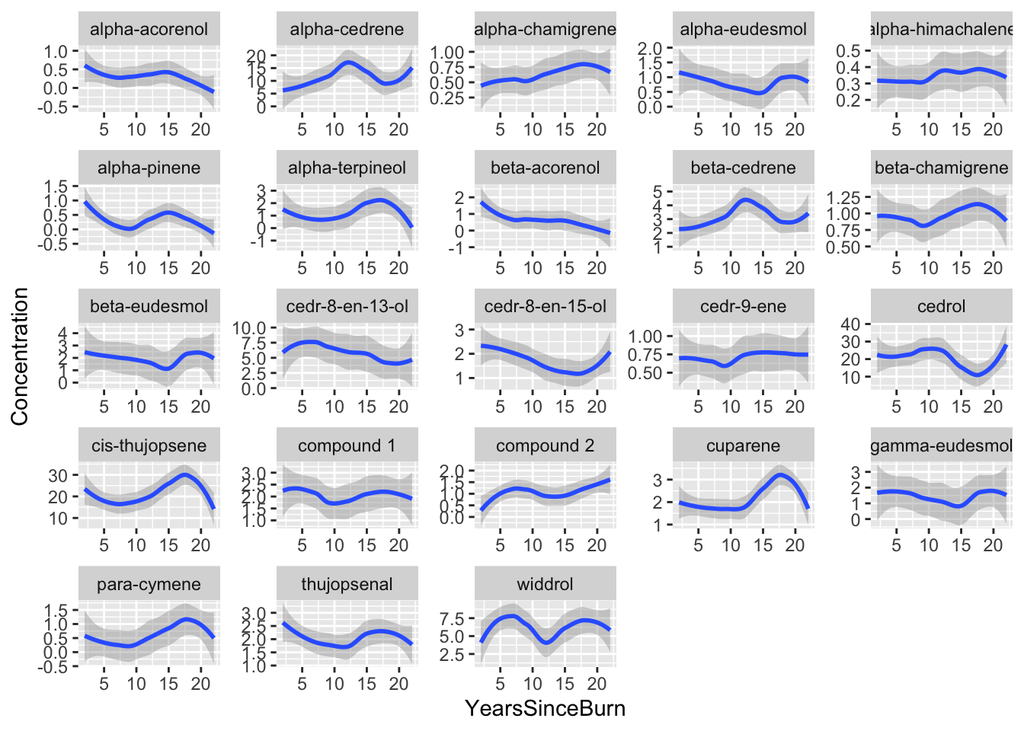

```r
cleanoil %>%
  ggplot(aes(x = YearsSinceBurn,y = Concentration))+
  geom_smooth()+
  facet_wrap(~ChemicalID, scales = "free")
```

**5. Use a generalized linear model to find which chemicals show concentrations that are significantly (significant, as in P < 0.05) affected by “Years Since Burn”.**

First let’s create a model looking at how the chemical type and years since burnt effects the concentration.

```r
mod2 <- glm(data=cleanoil,
            formula = Concentration~ChemicalID * YearsSinceBurn)
```

```r
m <- tidy(mod2) %>%
  mutate(term=term %>% str_remove_all("ChemicalID"))

m %>% filter(m$p.value<0.05)
```

```
## # A tibble: 6 × 5
##   term                          estimate std.error statistic  p.value
##   <chr>                            <dbl>     <dbl>     <dbl>    <dbl>
## 1 alpha-cedrene                    7.88      1.93       4.08 4.97e- 5
## 2 cedr-8-en-13-ol                  7.62      1.93       3.95 8.72e- 5
## 3 cedrol                          22.5       1.93      11.7  5.12e-29
## 4 cis-thujopsene                  17.3       1.93       8.95 2.93e-18
## 5 widdrol                          5.82      1.93       3.01 2.69e- 3
## 6 cis-thujopsene:YearsSinceBurn    0.332     0.141      2.35 1.90e- 2
```